# SHM 102: Occupational Health

Public Health History: Vaccination

Author

Yoni Rodriguez

Published

January 1, 2026

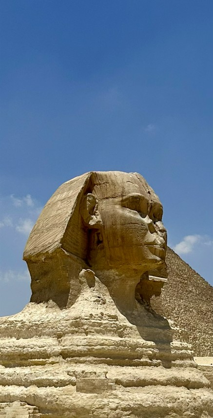

Great Sphinx of Giza, Egypt. Built around 2500 BCE; modern excavations began in 1817. Photograph by Yoni Rodriguez, May 13, 2024.

## SHM 102: Occupational Health

### Public Health History: Vaccination

**Lecture 04 · Fall 2026**

Yoni Rodriguez  
Engineering Technologies, Safety, and Construction  
Central Washington University  
Yoni.Rodriguez@cwu.edu

# Where Are We in Time?

Last class, we followed plague across more than **500 years** of scientific discovery.

Today, we are going to **rewind**.

Before we get started, let’s place ourselves back into the larger history of human health.

## From Human History to Microbiology

Our lectures have moved across thousands of years of human history.

**Where have we been, and where are we today?**

Lecture 02

Paleolithic Era

Prehistory · Before ~10,000 BCE

Lecture 02

Agricultural Revolution

Neolithic · ~10,000 BCE

Lecture 03

Black Death

14th Century · 1347–1351

Lecture 03

Microscopy

17th Century · 1676

↓ WE ARE HERE

Lecture 04

Vaccination

18th–19th Century · 1700s–1800s

Lecture 01

Modern Occupational Health

21st Century · 2020–2026

**NoteToday’s Historical Focus**

We are returning to the eighteenth century.

**How did people learn to prevent disease before they understood its biological cause?**

**NoteToday’s Window: 1717–1835**

Between the first observations of microorganisms and the establishment of germ theory, people were already learning how to **prevent disease** and **experimentally investigate its causes**.

Today we are zooming in on two developments:

1. **Smallpox prevention → variolation and vaccination**
2. **Microbial causation → Bassi and silkworm disease**

# A Question From Class

Earlier in the 2026 fall quarter, while discussing infectious disease and the development of germ theory, someone asked about **when were vaccines developed and who developed them?**

These questions dive into interesting public health and occupational health history

Edward Jenner conducted his famous vaccination experiment in **1796**.

But how did he get the idea to vaccinate someone?

## Poll Everywhere

### What Would You Look For?

Imagine it is **1796**.

You do not know what a virus is.

You do not know what antibodies are.

You do not know how the immune system works.

**What observations could convince you that someone might be protected from a disease?**

There is no single correct answer.

Think about what you could observe in individuals and populations.

# Smallpox

[figure not shown]

Smallpox lesions on the face of a child. Source: [World Health Organization, Smallpox Recognition Card](https://www.who.int/publications/m/item/who-smallpox-recognition-card); reproduced from *Smallpox and Its Eradication* (1988).

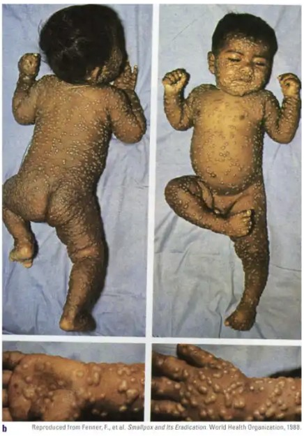

Smallpox lesions distributed across the body and extremities, with close-up views of lesions. Source: [World Health Organization, Smallpox Recognition Card](https://www.who.int/publications/m/item/who-smallpox-recognition-card); reproduced from *Smallpox and Its Eradication* (1988).

Smallpox was a highly contagious infectious disease that affected human populations for thousands of years.

People could observe:

- fever
- head and body aches
- early rash
- pustular rash and scabs
- death
- outbreaks moving through communities

**NoteAn Important Observation**

They could observe the **outcome**.

But there was another important observation.

### People who survived smallpox generally did not develop the disease again.

Something about surviving the disease appeared to change a person’s **susceptibility**.

## How Far Back Does Smallpox Go?

The origin of smallpox remains unknown.

However, historical and archaeological evidence suggests that diseases resembling smallpox affected human populations thousands of years ago.

### Ancient Egypt

The approximately **3,000-year-old mummy of Pharaoh Ramses V** has skin lesions that have been interpreted as resembling smallpox pustules.

This suggests that smallpox, or a disease with similar characteristics, may have existed in ancient Egypt.

However, the appearance of skin lesions alone cannot establish a definitive diagnosis.

**Important**

**The earliest origins of smallpox remain uncertain.**

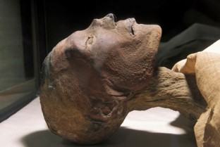

Head of the mummy of Pharaoh Ramses V, showing skin lesions historically interpreted as possible smallpox pustules. Source: [CDC, History of Smallpox](https://www.cdc.gov/smallpox/about/history.html). Original image credited to G. Elliot Smith, public domain.

### Historical Events by Century

Source: [CDC, History of Smallpox](https://www.cdc.gov/smallpox/about/history.html).

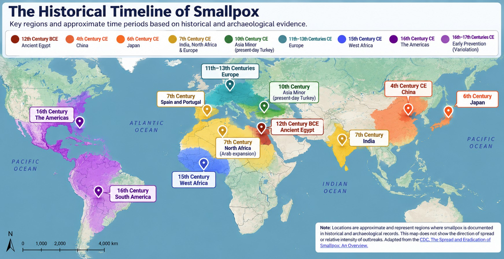

Figure 1: The Historical Timeline of Smallpox. Approximate regions and historical periods associated with evidence of smallpox [CDC, The Spread and Eradication of Smallpox](https://www.cdc.gov/smallpox/about/spread-and-eradication.html).

## What Changed as Smallpox Spread?

The movement of smallpox across regions was closely connected to human activity.

**Trade, migration, warfare, colonization, and forced displacement** created opportunities for infectious diseases to move between populations.

But people also began to recognize patterns.

Individuals who survived smallpox were generally protected against future disease.

That observation would eventually contribute to the development of deliberate methods of prevention.

### How could people use this observation to protect someone who had never experienced smallpox?

# An Observation Becomes an Intervention

If people who survived smallpox appeared protected from future smallpox…

### Could exposure somehow be used intentionally?

Long before modern vaccination, people in several parts of the world developed practices intended to protect individuals from smallpox.

One such practice became known as:

## Variolation

**Variolation** was the historical practice of deliberately exposing a person to material from smallpox lesions in an attempt to produce infection and subsequent protection.

The goal was to deliberately manipulate **exposure**.

But the exposure itself involved the disease people were trying to prevent.

## Poll Everywhere

### Would You Do It?

You are living in a community experiencing repeated smallpox outbreaks.

You have two choices:

**A.** Risk acquiring smallpox naturally.

**B.** Deliberately expose yourself to smallpox material in an attempt to develop protection.

**What additional information would you want before making that decision?**

Think about:

- probability of infection
- severity of disease
- probability of death
- whether the intervention actually provides protection
- risk to other people

# Evaluating the Risks of Variolation

Variolation was not harmless. It could cause severe smallpox, death, and transmission to others. Yet people also faced the risk of naturally acquired smallpox during epidemics.

The important question was not simply whether variolation was dangerous.

### How did the risks compare with doing nothing?

Historical reports from the **1721 Boston smallpox epidemic** described substantially lower mortality among people who underwent variolation than among those who acquired smallpox naturally. These were **historical observational comparisons**, not randomized clinical trials, and the groups may have differed in important ways.

**TipOccupational Health Connection: Comparative Risk**

A prevention decision requires comparing the potential harms and benefits of an intervention with the harms of the exposure it is intended to prevent.

**Historical reading:** Riedel S. (2005). [*Edward Jenner and the history of smallpox and vaccination*](https://pmc.ncbi.nlm.nih.gov/articles/PMC1200696/).

# Smallpox Prevention Before Jenner

## Variolation Was Not Jenner’s Invention

The idea of deliberately producing protection against smallpox existed **before Edward Jenner**.

Variolation was practiced in different forms in parts of **Asia and Africa** long before Jenner. It was also practiced in the **Ottoman Empire**, where European visitors encountered it.

### An Important Distinction

**Europeans did not invent smallpox inoculation when they began adopting it.** They learned about practices that other communities already used to reduce the danger of smallpox.

The history of vaccination therefore begins not only with European physicians, but also with **knowledge shared across cultures**.

**Historical reading:** Riedel S. (2005). [*Edward Jenner and the history of smallpox and vaccination*](https://pmc.ncbi.nlm.nih.gov/articles/PMC1200696/).

# Lady Mary Wortley Montagu

In the early eighteenth century, **Lady Mary Wortley Montagu** encountered smallpox inoculation while living in the Ottoman Empire.

Smallpox had affected her personally.

She had survived the disease, and her brother had died from it.

While in **Constantinople (present-day Istanbul)**, she observed an established Ottoman practice of deliberately inoculating people with smallpox material. Her writings described how people, including women who performed the procedure, practiced inoculation in their communities.

In **1718**, Montagu had her son inoculated while living in the Ottoman Empire. After returning to Britain, she had her daughter inoculated and advocated for broader adoption of the practice.

### What Was Montagu’s Contribution?

Montagu **did not invent inoculation**. She observed an existing practice, recognized its potential, and helped introduce that knowledge to British audiences.

**Historical reading:** Riedel S. (2005). [*Edward Jenner and the history of smallpox and vaccination*](https://pmc.ncbi.nlm.nih.gov/articles/PMC1200696/).

### Knowledge Was Moving

The scientific and medical knowledge we are following did not develop in one place or through one person.

**People observed practices in other cultures, learned from them, carried those ideas into new communities, and debated the evidence.**

This is a reminder that scientific knowledge does not move in only one direction, and that people outside formal European scientific institutions made important contributions.

# Another Path of Knowledge: Onesimus

At roughly the same time, knowledge of smallpox inoculation was also present in colonial North America.

In Boston, an enslaved African man named **Onesimus** described a form of smallpox inoculation to **Cotton Mather**.

The practice reflected knowledge carried from Africa.

During a major Boston smallpox epidemic, Mather promoted inoculation as a way to reduce the danger of the disease.

### More Than One Path

The history of smallpox prevention was not a simple sequence from one European scientist to another.

Knowledge moved through different communities and across continents:

**Africa and Asia → established inoculation practices**

**Ottoman Empire → Montagu → Britain**

**African knowledge → Onesimus → colonial Boston**

**TipScientific Knowledge Has Many Sources**

The history of occupational and public health includes not only formal scientific experiments, but also **observations, practices, and knowledge developed within communities**.

# But There Was a Problem

Variolation intentionally exposed someone to:

### smallpox.

That meant the intervention itself carried risk.

A variolated person could become seriously ill.

They could potentially transmit smallpox to other people.

**NoteThe Next Question**

**Could you produce protection without deliberately giving someone smallpox?**

# An Observation From the Countryside

## Cowpox

Cowpox was an infection associated with cattle that could also infect humans who had contact with infected animals.

People working around cattle sometimes developed cowpox lesions.

But a curious observation circulated:

### People who had experienced cowpox appeared less likely to develop smallpox.

## Look at the Occupation

Who would have repeated opportunities to encounter cowpox?

### People working with cattle.

Especially:

## milkmaids.

The occupation created an **opportunity for exposure**.

Remember what we learned from the plague investigation:

**The occupational hazard is not determined by the job title alone.**

It depends on the **task and opportunity for exposure**.

# Edward Jenner

English physician **Edward Jenner (1749–1823)** became interested in the relationship between **cowpox and smallpox**.

He had heard the observation that people who had previously developed cowpox seemed protected against smallpox.

But remember what we learned last class:

### An observation is not necessarily proof.

Jenner needed a way to test the hypothesis.

# The Hypothesis

## Observation

People exposed to cowpox sometimes appeared resistant to smallpox.

↓

## Question

Does infection with cowpox protect against smallpox?

↓

## Hypothesis

Previous exposure to cowpox provides protection against smallpox.

## Poll Everywhere

### How Would You Test It?

You have observed that people who previously experienced cowpox appear less likely to develop smallpox.

How could you test whether **cowpox actually provides protection against smallpox**?

Think about:

- what evidence you would collect
- what comparison you would make
- what outcome you would observe
- what would support or challenge the hypothesis

# Testing the Hypothesis

In **1796**, Jenner obtained material from a cowpox lesion on the hand of **Sarah Nelmes**, a milkmaid who had contracted cowpox.

He inoculated **James Phipps**, an eight-year-old boy, with the material.

Phipps developed symptoms consistent with cowpox and recovered.

Jenner later deliberately exposed Phipps to material from smallpox.

### Phipps did not develop smallpox.

Jenner subsequently conducted additional observations and experiments and published his findings in **1798**.

**ImportantHistorical Evidence and Modern Ethics**

Jenner’s experiment became historically important in the development of vaccination.

**It would not meet modern standards for ethical human-subjects research.**

Deliberately exposing a child to potentially lethal smallpox would be unacceptable under contemporary research ethics.

Scientific importance does not mean that every historical research method should be accepted by modern standards.

# Variolation vs. Vaccination

|  | **Variolation** | **Vaccination** |
| --- | --- | --- |
| **Exposure** | Smallpox material | Historically, cowpox material |
| **Goal** | Produce protection against smallpox | Produce protection against smallpox |
| **Smallpox exposure** | Yes | No |
| **Relative danger** | Greater | Lower |

# A New Intervention, Familiar Questions

Jenner’s vaccination avoided deliberately exposing people to smallpox itself. But it introduced another uncertainty: using material associated with **cowpox** to protect against a human disease.

People questioned its **safety**, **effectiveness**, and possible unintended consequences. The unfamiliar intervention also became a subject of satire and public debate.

# From Jenner to COVID-19

In **2020**, scientists faced another urgent challenge: preventing disease caused by a newly identified virus, **SARS-CoV-2**. Unlike Jenner, modern researchers could study viral genetic material, measure immune responses, and evaluate vaccines in clinical trials.

The technologies were different, but some public questions were familiar:

| **Early smallpox vaccination** | **COVID-19 vaccination** |
| --- | --- |
| Does it protect people? | Does it reduce disease and severe outcomes? |
| What are its risks? | What adverse effects occur, and how often? |
| How do we know it works? | What do laboratory studies and clinical trials show? |
| Whom should we trust? | How can evidence and uncertainty be communicated transparently? |

**Historical parallels do not mean the evidence, risks, or technologies were the same.** The lesson is that preventive interventions require both careful scientific evaluation and effective public communication.

### Occupational Health Connection

Workers may ask similar questions about respirators, exposure controls, vaccination recommendations, and new safety procedures.

**What is the evidence, what are the tradeoffs, and how should we communicate them?**

## Where Did “Vaccination” Come From?

The word **vaccination** traces to the Latin:

### *vacca* = cow

Jenner used the term *variolae vaccinae* in describing cowpox.

Eventually, **vaccination** became the broader term for inducing protection against infectious disease.

# But How Did It Work?

Jenner could observe that vaccination worked.

He could collect evidence that vaccination worked.

### But he could not explain the mechanism using modern immunology.

He did not know about:

- viruses
- antibodies
- B cells
- T cells
- immune memory

That understanding came later.

**ImportantPrevention Can Precede Complete Understanding**

People practiced **quarantine** before identifying *Yersinia pestis*.

People practiced **variolation** before understanding viruses or immunity.

Jenner demonstrated protection through **vaccination** before modern immunology existed.

### Effective prevention does not always require complete understanding of the underlying mechanism.

# Now We Change the Question

We have spent much of this lecture asking:

> **Can we prevent disease without completely understanding its cause?**

But scientists were also pursuing another question:

> **Can we experimentally demonstrate that a microorganism causes disease?**

# Italy, 1830s

## Another Disease Was Causing a Different Problem

This time, the victims were not humans.

They were:

# silkworms.

Silk production depended on raising large numbers of silkworms.

Disease among silkworm populations therefore threatened:

- animals
- production
- livelihoods
- workers
- an important industry

Again, disease existed inside a **system**.

# Agostino Bassi

Italian scientist **Agostino Bassi** spent years investigating a disease affecting silkworms.

The disease was known as **mal del segno**, or **muscardine**.

Bassi eventually demonstrated that the disease was caused by a **fungus**.

That was enormously important.

### A microorganism had been experimentally demonstrated to cause disease in an animal.

# Remember Our Question?

Last class, after introducing microscopy, we asked:

> **Seeing a microorganism does not necessarily mean that it caused the disease.**

What additional evidence would you want?

Bassi helped demonstrate an answer.

Scientists could:

1. observe disease
2. identify a suspected biological agent
3. transmit disease using material associated with that agent
4. observe the disease developing in another organism

### Observation was becoming experimentation.

# One Health Before “One Health”

## The System

**Silkworm**

↓

**Fungal pathogen**

↓

**Disease**

↓

**Silk production**

↓

**Workers and livelihoods**

↓

**Economic consequences**

### Is this an animal-health problem?

**Yes.**

### Is this an economic problem?

**Yes.**

### Is this an occupational problem?

**Yes.**

### Is this an environmental or biological problem?

**Yes.**

The parts of the system are connected.

# Two Different Scientific Problems

| **Jenner** | **Bassi** |
| --- | --- |
| Can disease be prevented? | Can disease be experimentally attributed to a microorganism? |
| Observation of population pattern | Observation of diseased animals |
| Cowpox → apparent protection | Fungus → silkworm disease |
| Intervention | Causal investigation |
| Prevention before mechanism | Evidence of microbial causation |

### Which came first?

In the smallpox story:

## Reliable prevention came before complete mechanistic understanding.

# What Humans Could Now Do

By the middle of the nineteenth century, humans had become increasingly capable of:

## OBSERVING

patterns of disease

↓

## FORMING HYPOTHESES

about what caused disease

↓

## SEEING

the microscopic world

↓

## EXPERIMENTING

with suspected causes

↓

## PREVENTING

some diseases even before mechanisms were completely understood

# But Another Tool Was Developing

Scientists could also study:

### patterns of disease across populations.

They could ask:

- Who became sick?
- Where did they live or work?
- When did illness occur?
- What exposures did affected people share?
- Were some groups affected more than others?

Those patterns could provide evidence even when the hazard itself could not yet be directly identified.

# From Vaccination to Occupational Health

## Think Like an Occupational Health Scientist

The historical cases changed.

The investigative questions did not.

When workers experience illness, ask:

- What health outcome are we observing?
- Who is affected?
- What exposures do they share?
- What tasks create opportunities for exposure?
- What evidence supports a causal relationship?
- Can we intervene before every mechanism is completely understood?
- What additional evidence would strengthen our conclusion?

**TipDecisions Under Uncertainty**

**Occupational health often requires decisions under uncertainty.**

Waiting until every biological mechanism is completely understood may allow preventable exposures to continue.

# The Next Mystery

## London, 1854

Thousands of people are becoming sick.

The disease is:

# cholera.

People disagree about what is causing it.

Some blame contaminated air.

Others suspect something else.

You do not have modern laboratory testing.

You cannot simply identify the organism in your laboratory.

### How could you determine where the exposure is coming from?

## Next: John Snow, Cholera, and Epidemiology

# Key Takeaway

Humans learned to prevent some diseases **before they completely understood their causes**.

Smallpox demonstrated that careful observation could reveal patterns of **susceptibility and protection**.

Variolation showed that exposure could be deliberately manipulated to produce protection, although the practice carried substantial risk.

Jenner’s experiments with cowpox helped establish **vaccination** as a safer approach to preventing smallpox.

Bassi’s investigation of silkworm disease provided early experimental evidence that a **microorganism could cause disease in an animal**.

### Scientific understanding developed incrementally.

**Observation → hypothesis → intervention → experimentation → evidence**

In occupational health, we often face the same challenge:

### How much evidence do we need before we act to prevent harm?

# Selected Historical Reading

Riedel, S. (2005). [Edward Jenner and the history of smallpox and vaccination](https://pmc.ncbi.nlm.nih.gov/articles/PMC1200696/). *Proceedings (Baylor University Medical Center), 18*(1), 21–25.

# Key Terms

| Term | Definition |
| --- | --- |
| **Immunity** | Protection against a particular infectious disease resulting from the body’s ability to respond to the infectious agent. |
| **Variolation** | Historical practice of deliberately exposing a person to smallpox material to produce infection and subsequent protection. |
| **Vaccination** | Administration of a vaccine to produce protection against disease. |
| **Vaccine** | A preparation used to stimulate protection against a particular disease. |
| **Causation** | A relationship in which an exposure or factor contributes to producing an outcome. |
| **Susceptible host** | A person or animal capable of becoming infected by an infectious agent. |

## Make your flashcards

### Copy → Paste → Study

Copy the terms below to make your own **Anki or Quizlet** flashcards.

**Anki:** Save as a `.txt` file → Import → Select **Semicolon** as the field separator.

```
Immunity;Protection against a particular infectious disease resulting from the body's ability to respond to the infectious agent.
Variolation;Historical practice of deliberately exposing a person to smallpox material to produce infection and subsequent protection.
Vaccination;Administration of a vaccine to produce protection against disease.
Vaccine;A preparation used to stimulate protection against a particular disease.
Causation;A relationship in which an exposure or factor contributes to producing an outcome.
Susceptible host;A person or animal capable of becoming infected by an infectious agent.
```

### Copyright & Use

**SHM 102: Occupational Health**  
© 2026 Yoni Rodriguez

Except where otherwise noted, original course materials are licensed under the Creative Commons Attribution-NonCommercial 4.0 International License (CC BY-NC 4.0).

Third-party materials remain subject to their respective copyright and licensing terms.